# PRJEB13583 Expression Correction

Nicolas Delhomme

2017-10-25

# 1 Rationale

As observed during the biological QA, there is a bias in the expression measurements. As the samples go inward the wood, less genes are expressed (presumably because of lower amount of materials leading to an overall lower sequencing depth), which was over-compsensated by the library size correction, resulting in an average increase of gene expression across sections from the phloem to the xylem.

# 2 Setup

Set the working dir

```r
setwd("/mnt/picea/projects/aspseq/facility/PRJEB13583/Potri03")
```

Load libraries

```r
suppressPackageStartupMessages(library(gplots))
suppressPackageStartupMessages(library(hyperSpec))
suppressPackageStartupMessages(library(S4Vectors))
suppressPackageStartupMessages(library(pander))
suppressPackageStartupMessages(library(RColorBrewer))
suppressPackageStartupMessages(library(VennDiagram))
```

Source some helper functions

```r
suppressMessages(source("~/Git/UPSCb/src/R/expressionSpecificityUtility.R"))
suppressMessages(source("~/Git/UPSCb/src/R/featureSelection.R"))
```

Create a palette

```r
pal <- brewer.pal(8,"Dark2")
hpal <- colorRampPalette(c("blue","white","red"))(100)
```

Register the default plot margin

```r
mar <- par("mar")
```

Raw data

```r
vst <- read.csv("analysis/HTSeq/library-size-normalized_variance-stabilized_PRJEB13583_ctl-selected_frc-data.csv",row.names = 1)
```

Sample information

```r
samples <- read.csv("~/Git/UPSCb/projects/facility-immanen-et-al/doc/PRJEB13583-Ctl-bestaligned frc.csv")
samples$othernames <- sprintf("AF%02d",as.integer(sub("AF","",samples$othernames)))
ord <- order(samples$Tree,samples$othernames)
samples <- samples[ord,]
stopifnot(all(colnames(vst)==samples$SampleID))

nams <- paste(samples$Tree,samples$othernames,sep="-")
```

# 3 Correction

Split data in expression bins (10 of 10% each)

```r
v <- apply(vst,2,function(co){split(co,cut(co,10))})
```

There is clearly a linear relationship in every bin. Also, albeit less apparent, the log fold change range of the bins increase with the bin average expression

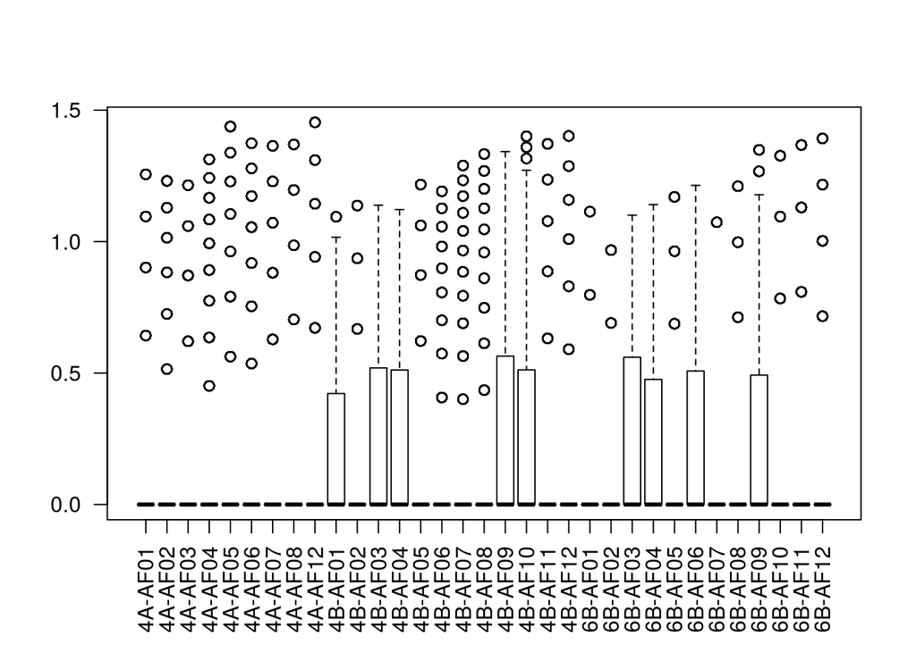

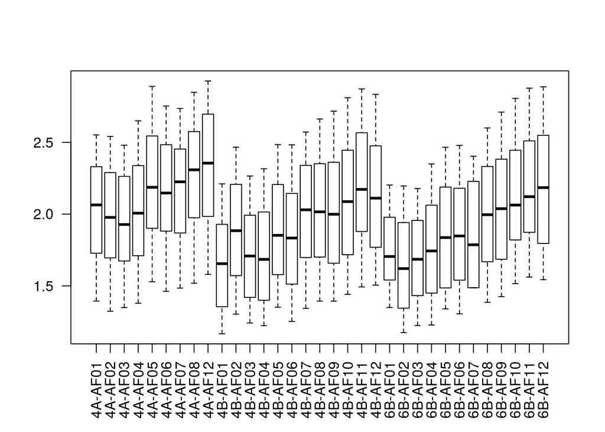

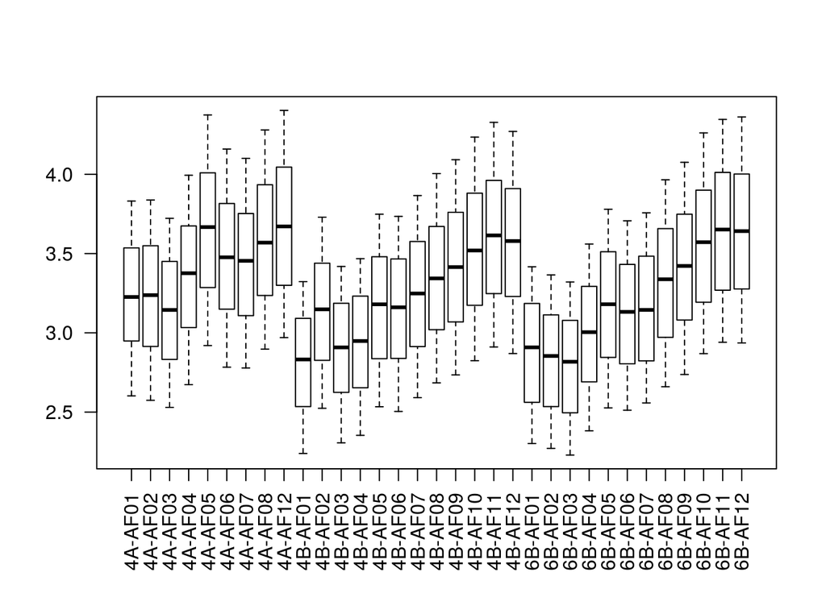

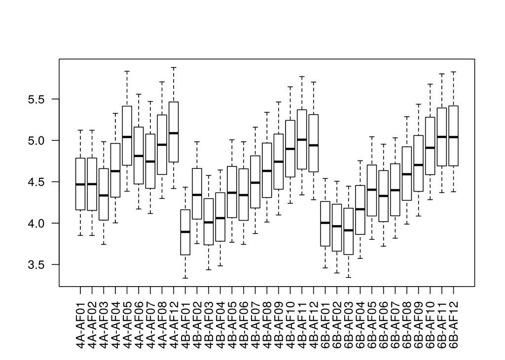

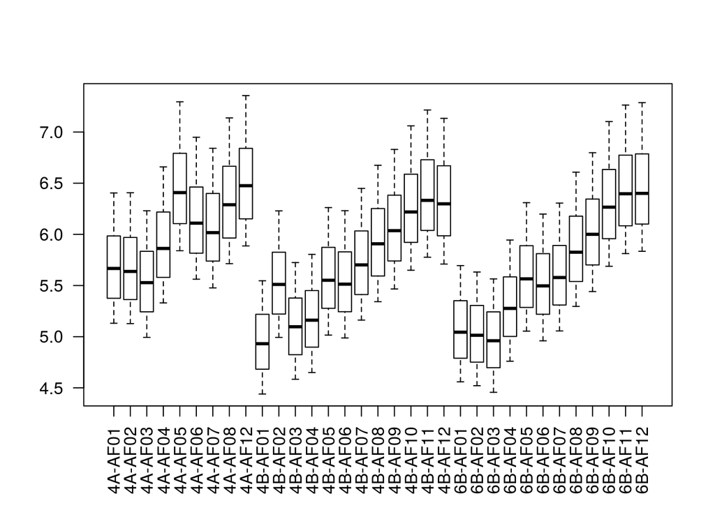

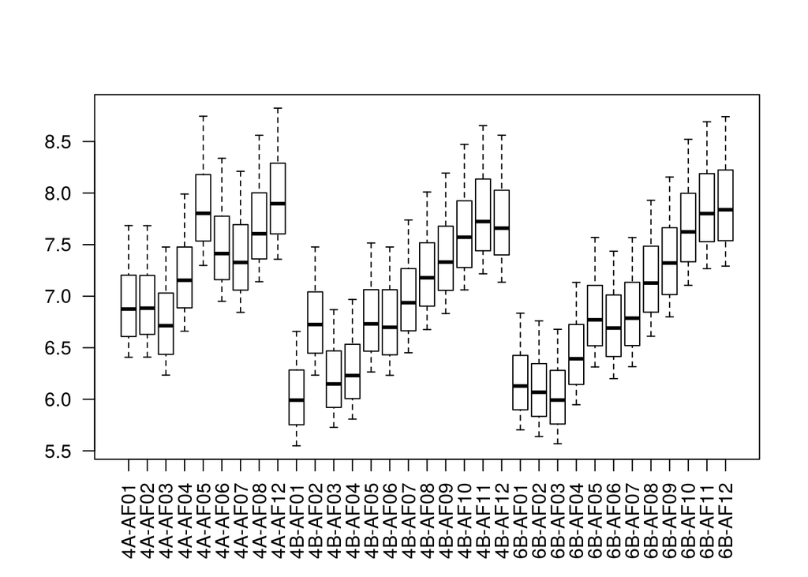

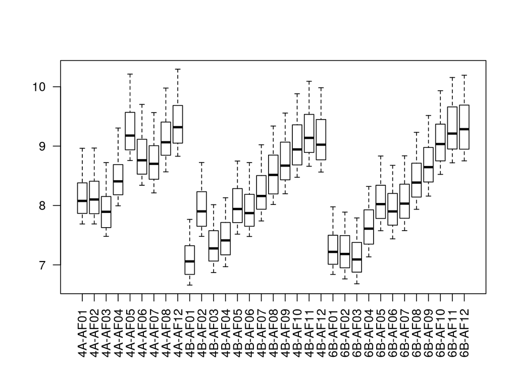

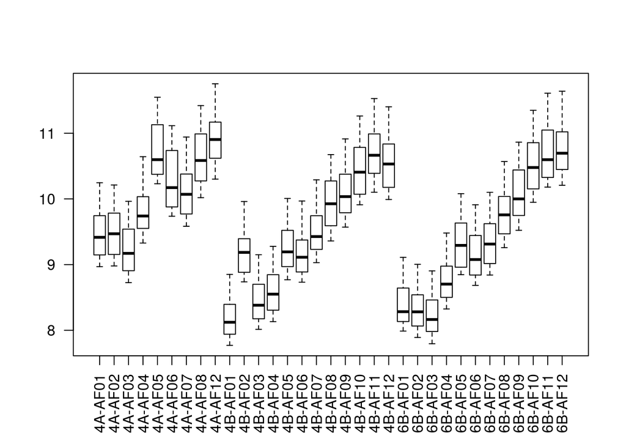

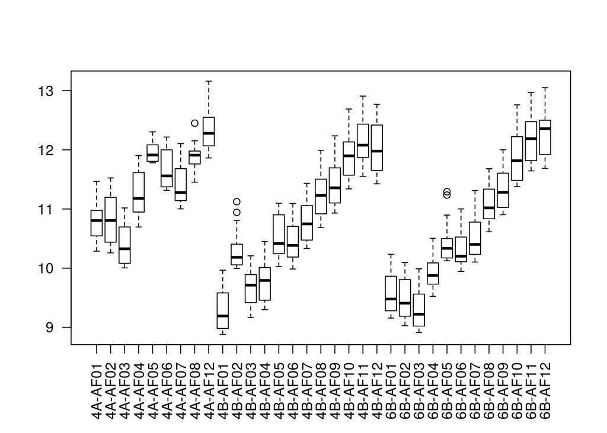

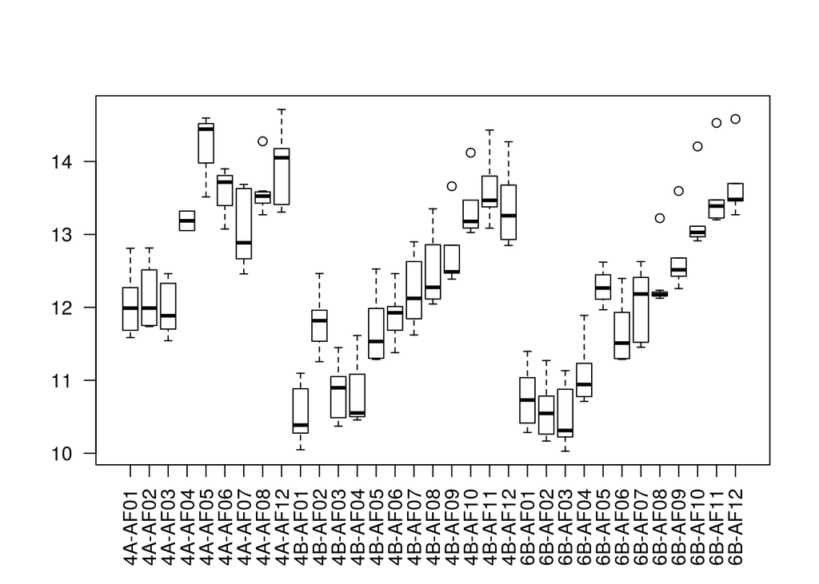

```r
dev.null <- sapply(1:10,function(i){
  boxplot(lapply(v,"[[",i),las=2,names=nams)}
)
```

Model the relationship for the three datasets, per bin

```r
lms <- sapply(1:10,function(i){
  x1 <- 1:9
  x2 <- x3 <- 1:12
  y1 <- sapply(lapply(v,"[[",i),median)[1:9]
  y2 <- sapply(lapply(v,"[[",i),median)[10:21]
  y3 <- sapply(lapply(v,"[[",i),median)[22:33]
  l1 <- lm(y1~x1)
  l2 <- lm(y2~x2)
  l3 <- lm(y3~x3)
  return(c(l1$coefficients["x1"],
           l2$coefficients["x2"],
           l3$coefficients["x3"]))
})

dimnames(lms) <- list(levels(samples$Tree),sprintf("Bin%02d",1:10))
pander(lms)
```

Table continues below

|  | Bin01 | Bin02 | Bin03 | Bin04 | Bin05 | Bin06 | Bin07 |
| --- | --- | --- | --- | --- | --- | --- | --- |
| **4A** | 0 | 0.04823 | 0.05827 | 0.08177 | 0.1069 | 0.129 | 0.1638 |
| **4B** | 0 | 0.04379 | 0.06856 | 0.09819 | 0.1255 | 0.1552 | 0.1844 |
| **6B** | 0 | 0.05007 | 0.08079 | 0.1098 | 0.1433 | 0.1805 | 0.2133 |

|  | Bin08 | Bin09 | Bin10 |
| --- | --- | --- | --- |
| **4A** | 0.1922 | 0.1916 | 0.2564 |
| **4B** | 0.2235 | 0.2575 | 0.2605 |
| **6B** | 0.2506 | 0.2942 | 0.2905 |

Then model the increase with expression for the three datasets

```r
x<-1:10
y1 <- lms[1,]
l1 <- lm(y1~x)

y2 <- lms[2,]
l2 <- lm(y2~x)

y3 <- lms[3,]
l3 <- lm(y3~x)
```

Plot the results

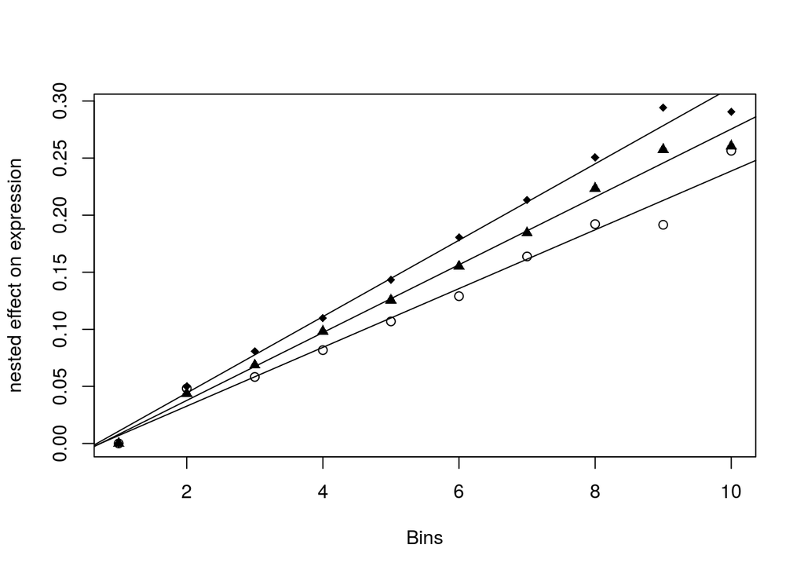

```r
plot(1:10,lms[1,],ylim=range(lms),
     xlab="Bins",ylab="nested effect on expression")
points(lms[2,],pch=17)
points(lms[3,],pch=18)
abline(l1)
abline(l2)
abline(l3)
```

## 3.1 Corrected matrix

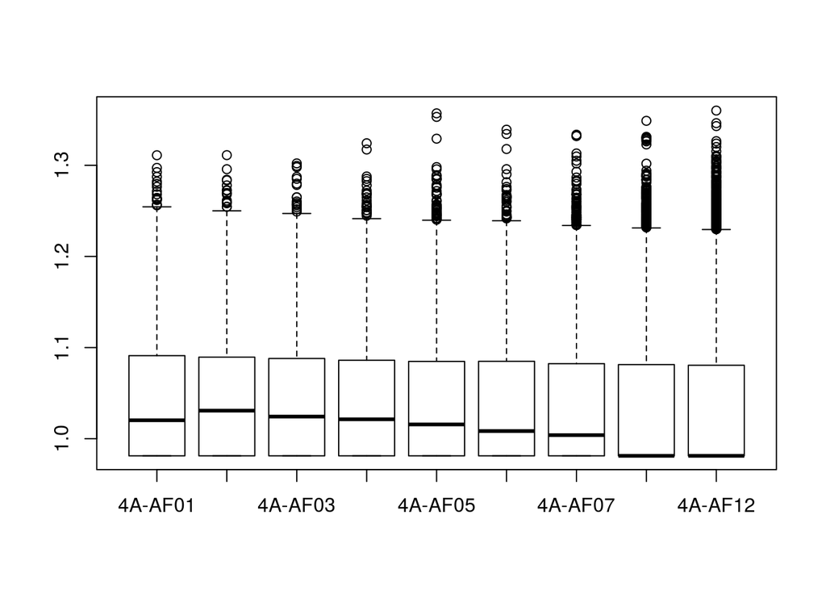

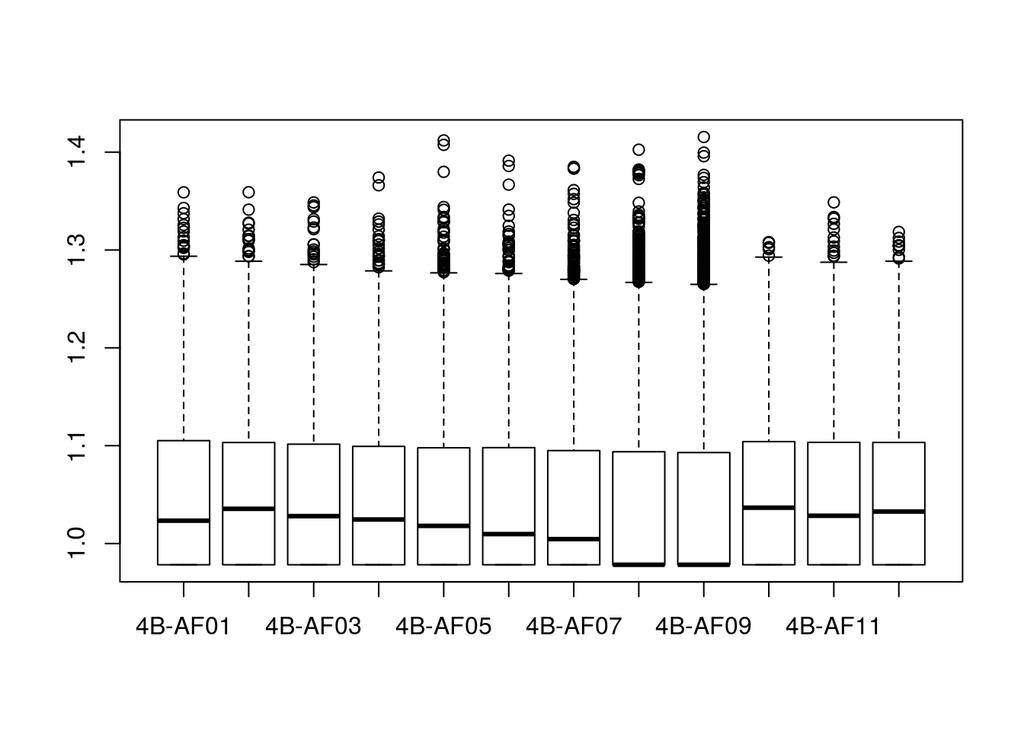

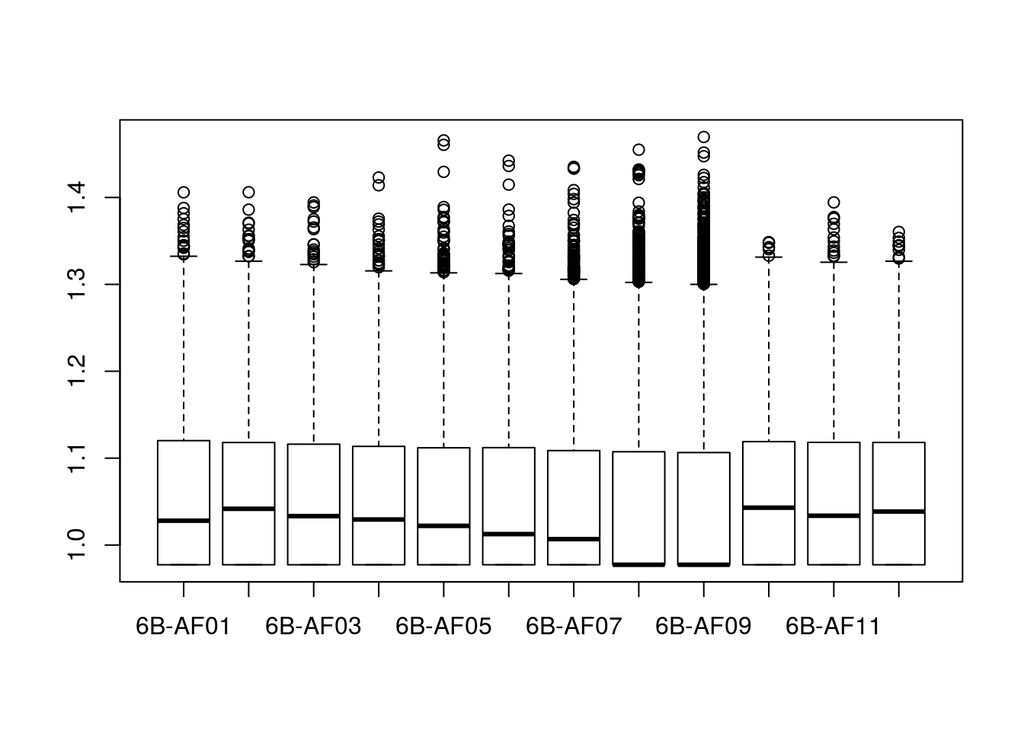

```r
c.vst <- do.call(cbind,lapply(1:nlevels(samples$Tree),function(i,dat,smpl,preds){

  # get the data
  sel <- smpl$Tree==levels(smpl$Tree)[i]
  d <- dat[,sel]

  # create a correction matrix
  mat <- matrix(1,nrow=nrow(d),ncol=ncol(d))

  # predict the effect
  res <- sapply(1:ncol(d),function(i,p){
    predict(p,data.frame(x=dat[,i]))
  },preds[[i]])

  mat <- mat * (1 + res)

  boxplot(mat,names=nams[sel])

  # apply the correction
  d * (1 / mat)

},vst,samples,list(l1,l2,l3)))
```

### 3.1.1 Boxplots

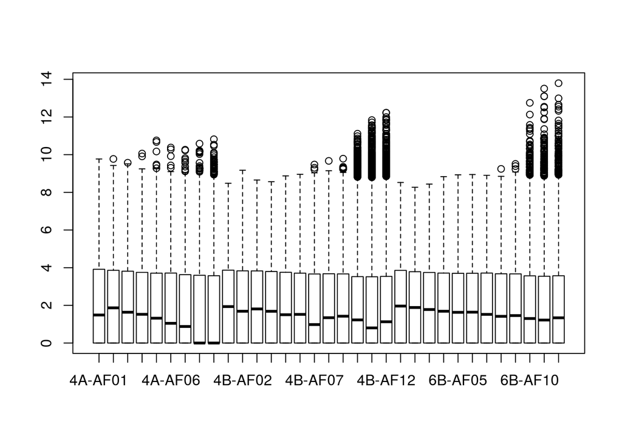

```r
boxplot(c.vst,names=nams)
```

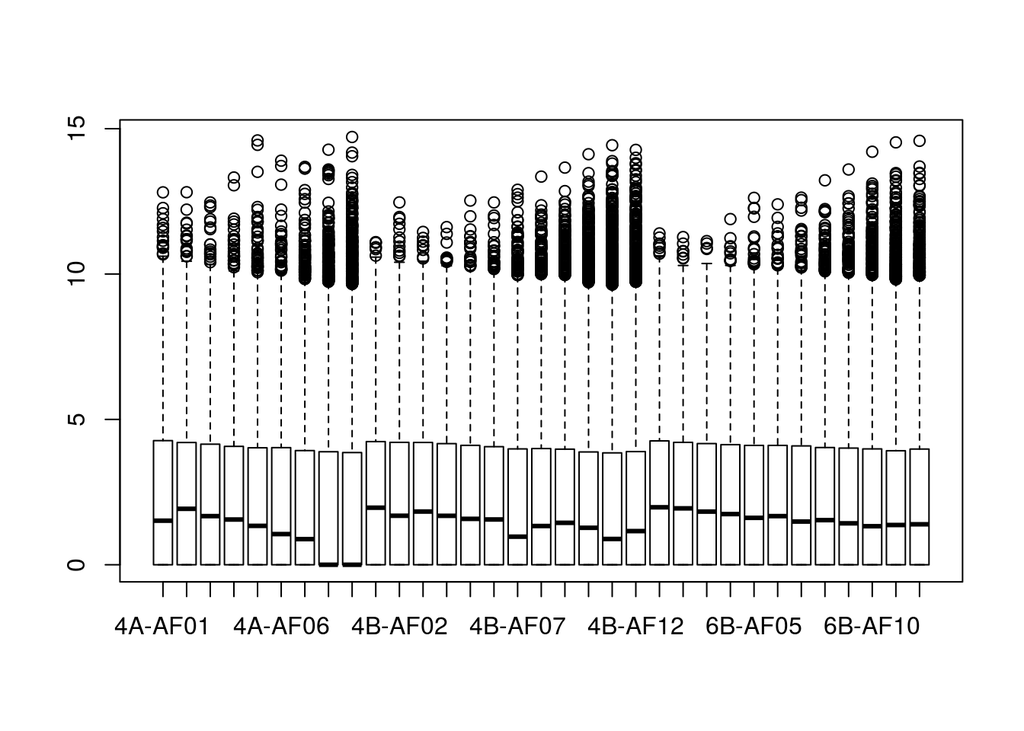

```r
boxplot(vst,names=nams)
```

### 3.1.2 Bins

Bin the corrected expression

```r
n.c <- apply(c.vst,2,function(co){split(co,cut(co,10))})
```

And compare it to the non corrected one

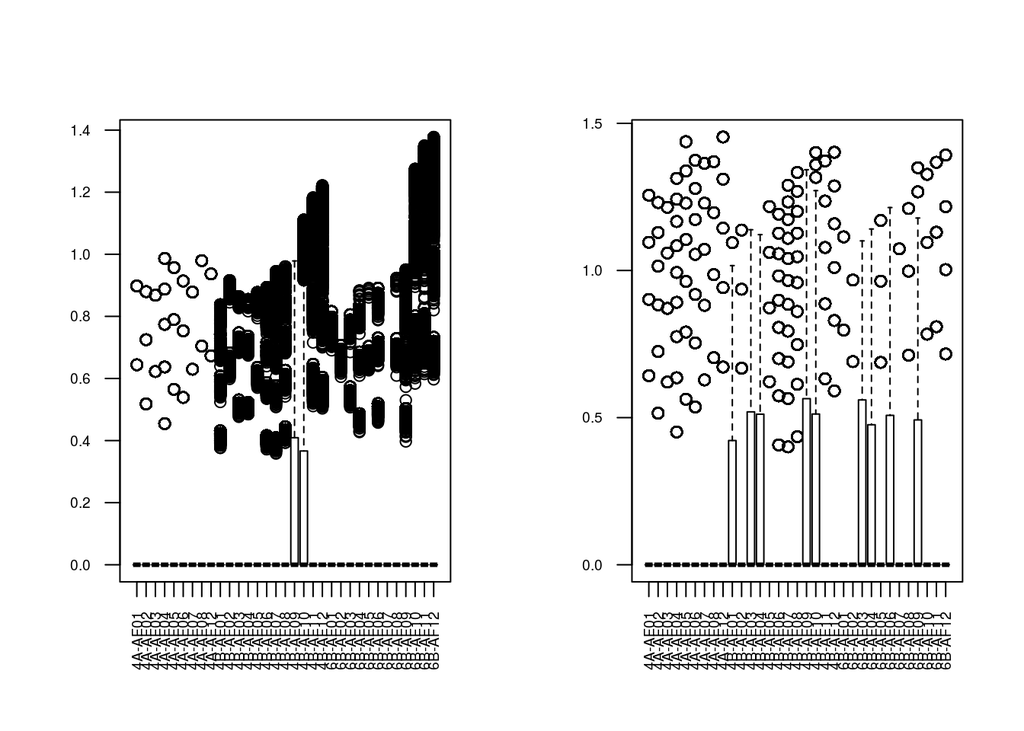

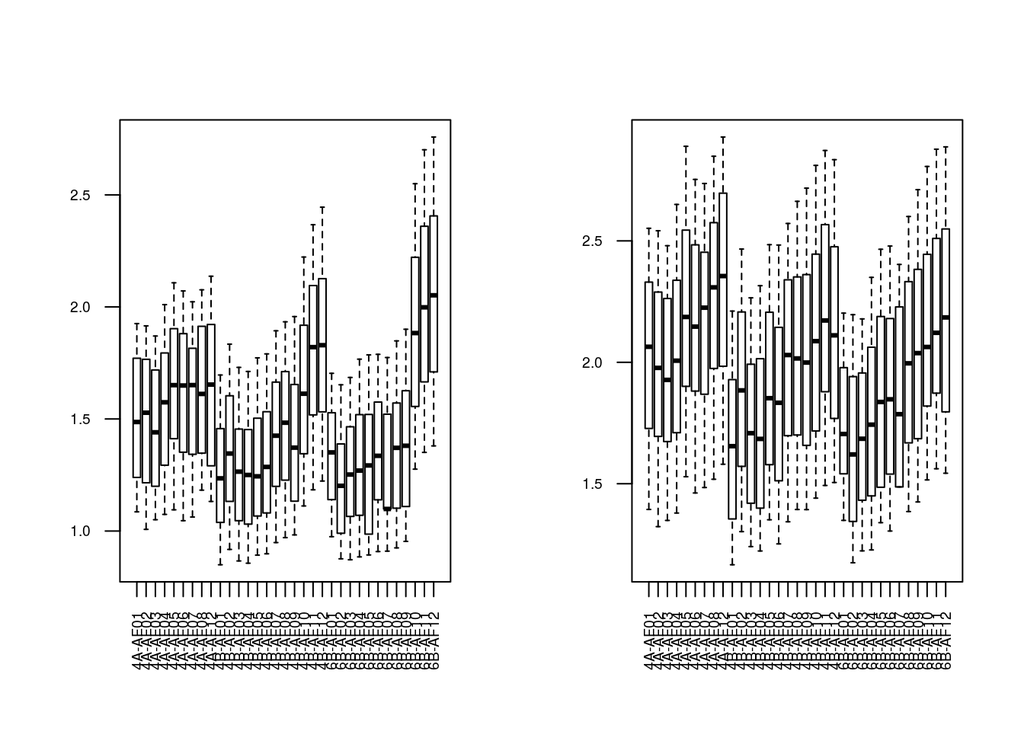

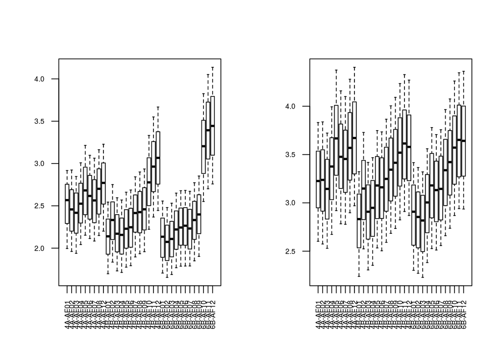

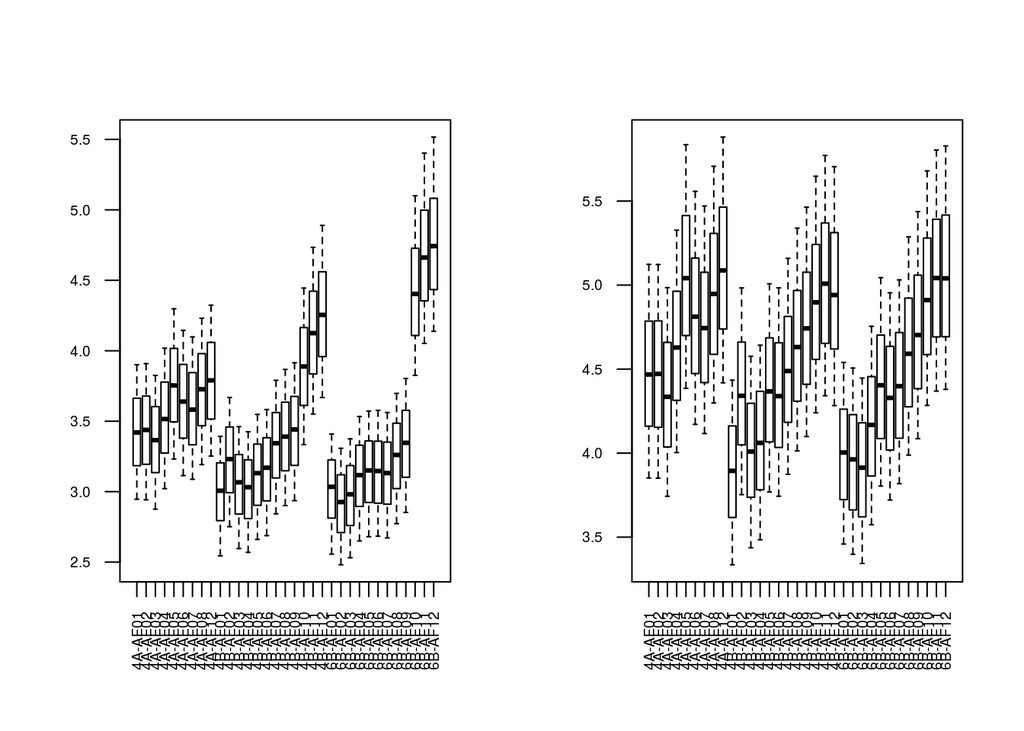

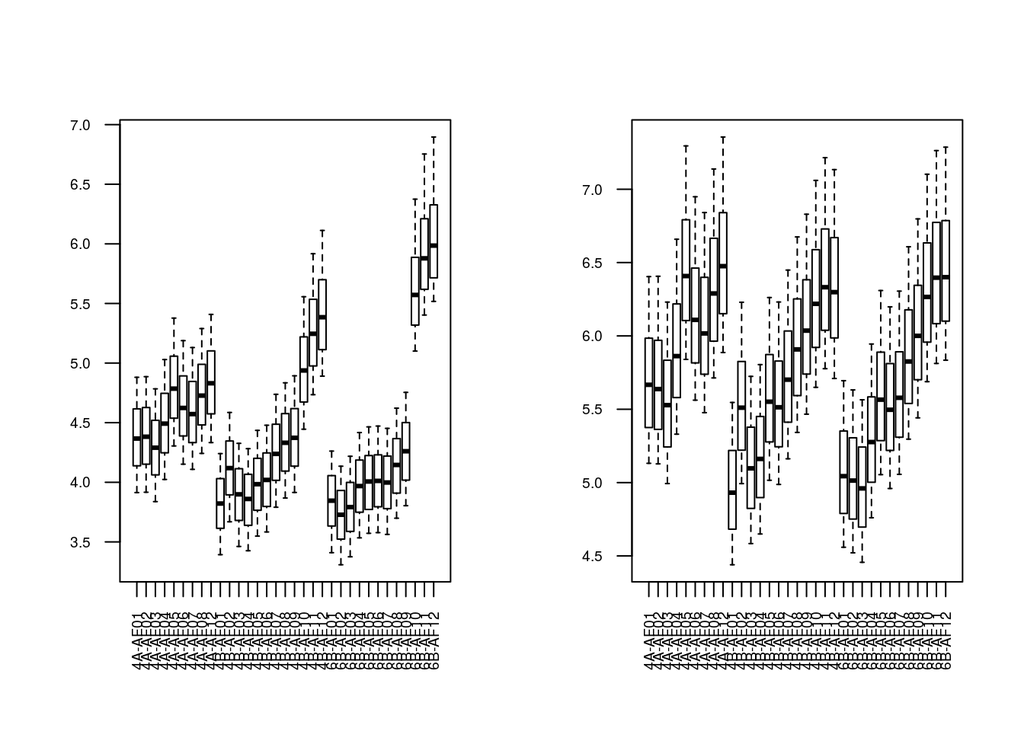

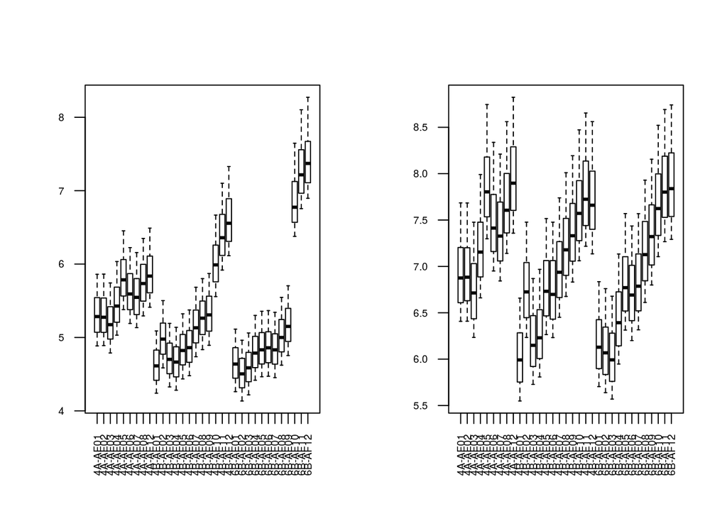

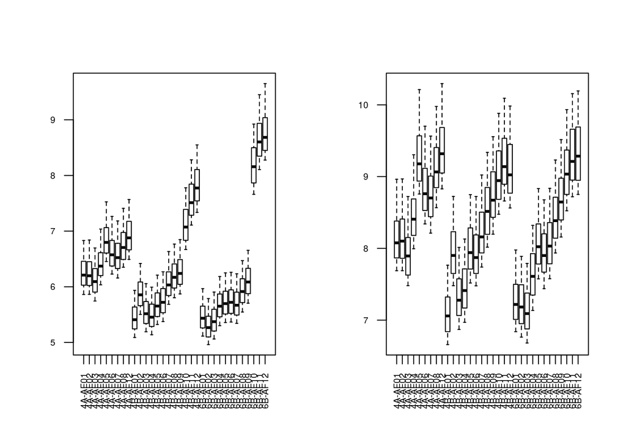

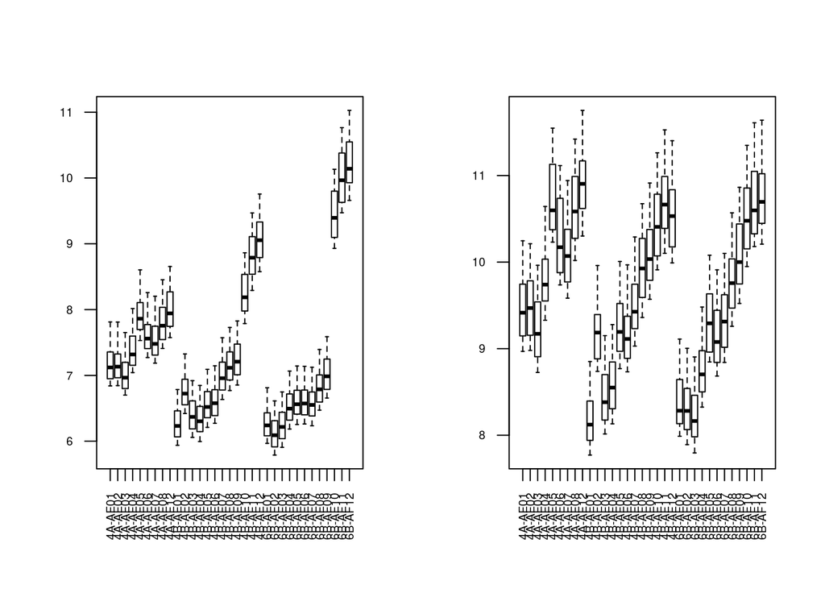

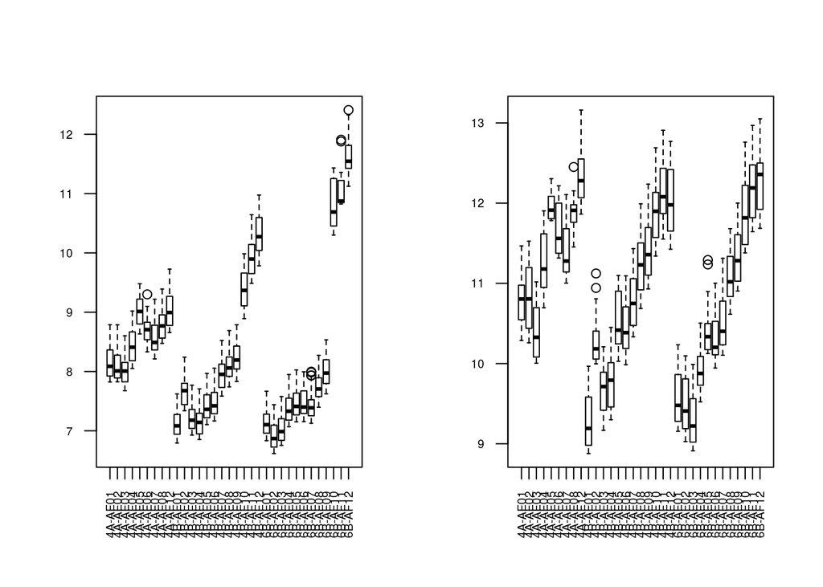

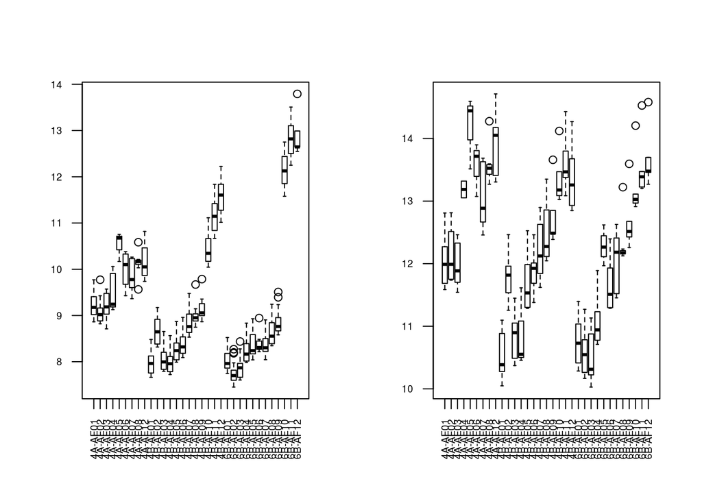

```r
par(mfrow=c(1,2))
dev.null <- sapply(1:10,function(i){
  boxplot(lapply(n.c,"[[",i),las=2,names=nams,cex.axis=0.6)
  boxplot(lapply(v,"[[",i),las=2,names=nams,cex.axis=0.6)
})
```

```r
n.lms <- sapply(1:10,function(i){
  x1 <- 1:9
  x2 <- x3 <- 1:12
  y1 <- sapply(lapply(n.c,"[[",i),median)[1:9]
  y2 <- sapply(lapply(n.c,"[[",i),median)[10:21]
  y3 <- sapply(lapply(n.c,"[[",i),median)[22:33]
  l1 <- lm(y1~x1)
  l2 <- lm(y2~x2)
  l3 <- lm(y3~x3)
  return(c(l1$coefficients["x1"],
           l2$coefficients["x2"],
           l3$coefficients["x3"]))
})
dimnames(n.lms) <- list(levels(samples$Tree),sprintf("Bin%02d",1:10))
pander(n.lms)
```

Table continues below

|  | Bin01 | Bin02 | Bin03 | Bin04 | Bin05 | Bin06 | Bin07 |
| --- | --- | --- | --- | --- | --- | --- | --- |
| **4A** | 0 | 0.0236 | 0.03215 | 0.04839 | 0.05975 | 0.07487 | 0.08773 |
| **4B** | 0 | 0.05143 | 0.07829 | 0.1068 | 0.1344 | 0.1665 | 0.2015 |
| **6B** | 0 | 0.06941 | 0.1226 | 0.1602 | 0.2 | 0.252 | 0.3078 |

|  | Bin08 | Bin09 | Bin10 |
| --- | --- | --- | --- |
| **4A** | 0.107 | 0.1195 | 0.1496 |
| **4B** | 0.2415 | 0.2736 | 0.3044 |
| **6B** | 0.3606 | 0.4018 | 0.4592 |

```r
y1 <- n.lms[1,]
l1c <- lm(y1~x)

y2 <- n.lms[2,]
l2c <- lm(y2~x)

y3 <- n.lms[3,]
l3c <- lm(y3~x)
```

Plot the results

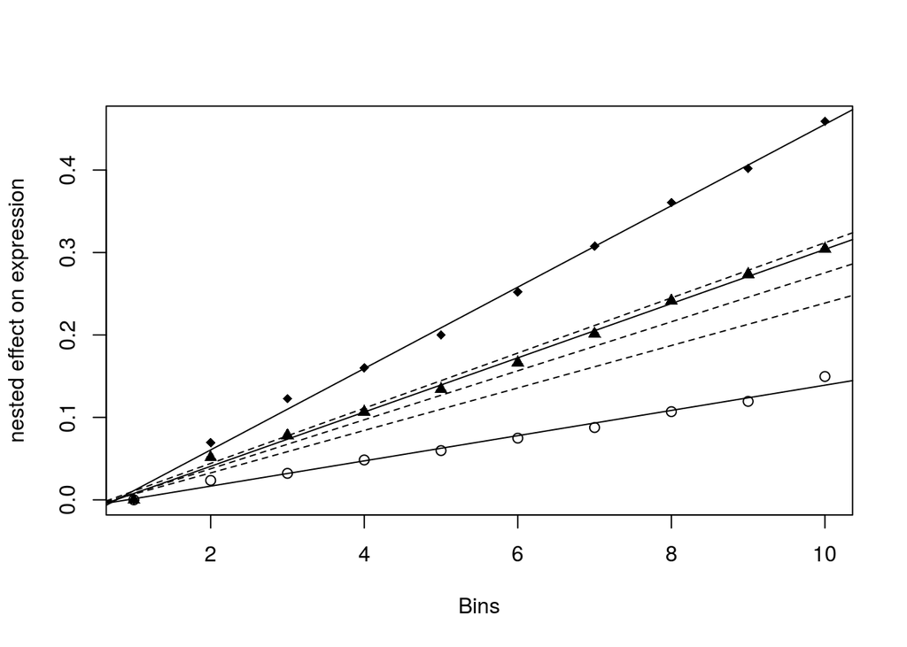

```r
plot(1:10,n.lms[1,],ylim=range(n.lms),
     xlab="Bins",ylab="nested effect on expression")
points(n.lms[2,],pch=17)
points(n.lms[3,],pch=18)
abline(l1c)
abline(l2c)
abline(l3c)
abline(l1,lty=2)
abline(l2,lty=2)
abline(l3,lty=2)
```

Look at the number of genes

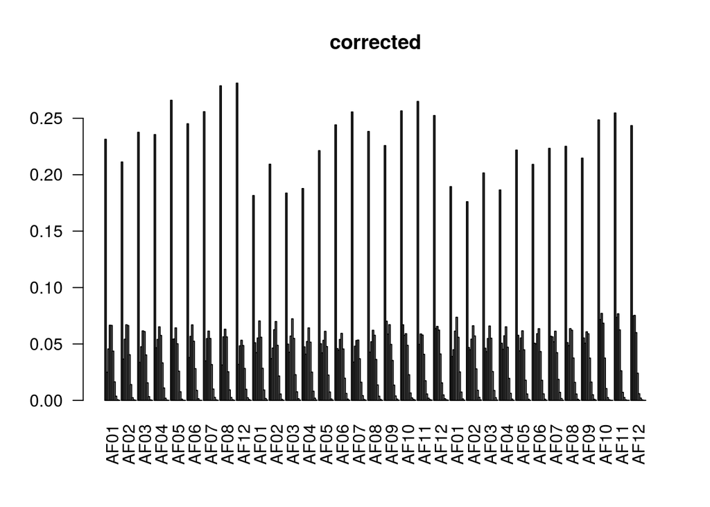

```r
par(mfrow=c(1,1))
barplot(sapply(n.c,elementNROWS)/colSums(c.vst),
        beside = TRUE,main="corrected",las=2,
        names.arg = samples$othernames)
```

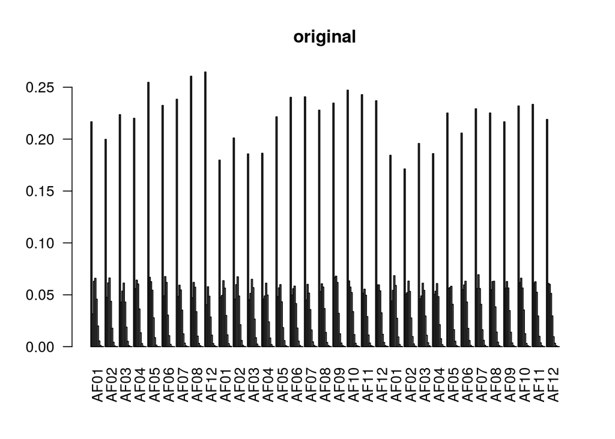

```r
barplot(sapply(v,elementNROWS)/colSums(vst),
        beside = TRUE,main="original",las=2,
        names.arg = samples$othernames)
```

### 3.1.3 Heatmap

Select the feature

```r
v.sel <- featureSelect(as.matrix(vst),factor(samples$othernames)
                     ,exp=3,nrep=2)
c.sel <- featureSelect(as.matrix(c.vst),factor(samples$othernames)
                       ,exp=3,nrep=2)
```

How many overlap

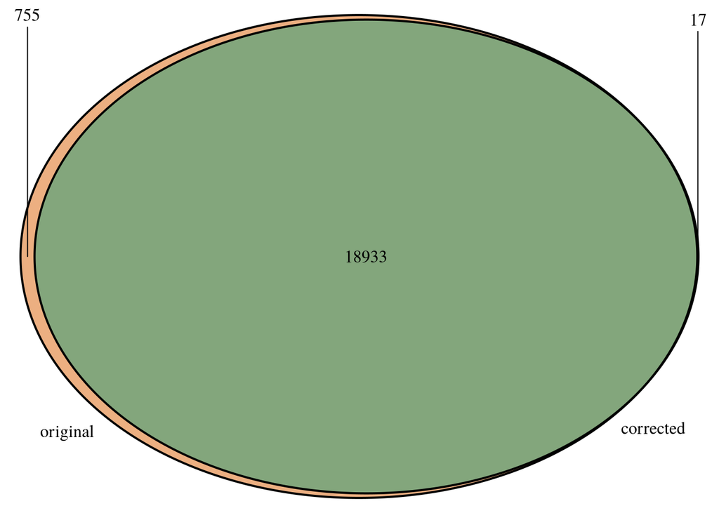

```r
plot.new()
grid.draw(venn.diagram(list(corrected=rownames(c.vst)[c.sel],
                            original=rownames(vst)[v.sel]),
                        filename=NULL,fill=pal[1:2]))
```

scale the data

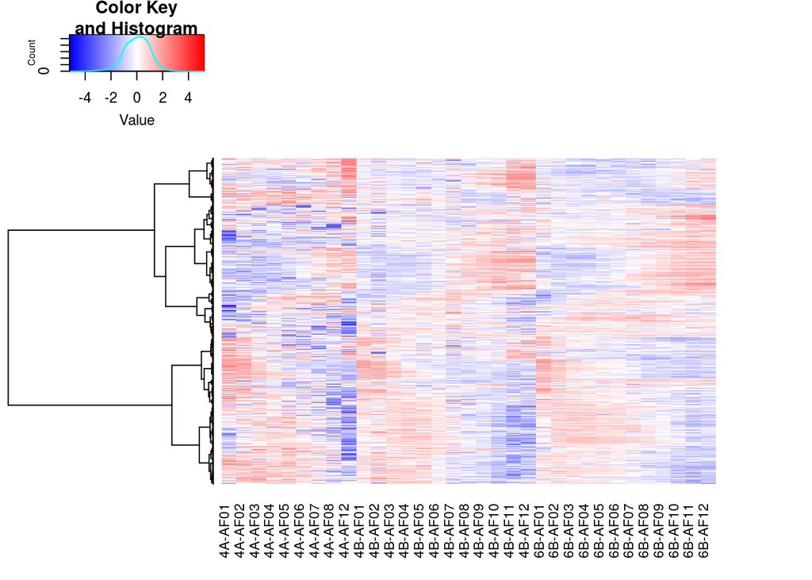

```r
s.v <- t(scale(t(vst)))
n.s <- t(scale(t(c.vst)))

heatmap.2(s.v[v.sel,],distfun = pearson.dist,Colv=FALSE,dendrogram="row",
          hclustfun = function(X){hclust(X,method="ward.D")},
          labRow=NA,trace="none",
          las=2,col=hpal,labCol=nams)
```

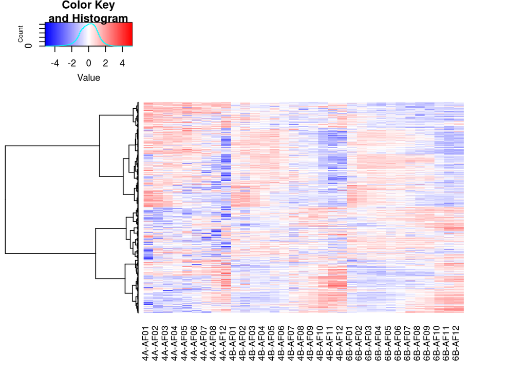

```r
heatmap.2(n.s[c.sel,],distfun = pearson.dist,Colv=FALSE,dendrogram="row",
          hclustfun = function(X){hclust(X,method="ward.D")},
          labRow=NA,trace="none",
          las=2,col=hpal,labCol=nams)
```